# Statistical Inference

# 16 Resample Inference

- **Intro**: Resampling based procedures are ways to perform population based statistical inferences, while living within our data. Data Scientists tend to really like resampling based inferences, since they are very data centric procedures, they scale well to large studies and they often make very few assumptions.

## 16.1 Bootstrap

- **Bootstrap** = tremendously useful tool for constructing confidence intervals and caclulating standard errors for statistics that might be difficult for some reason (e.g., lack of data or no closed form)
- Wikipedia tells us that bootstrapping is a technique which “allows estimation of the sampling distribution of almost any statistic using very simple methods.”
- The beauty of bootstrapping is that it avoids complicated mathematics and instead uses simulation and computation to infer distributional properties you might not otherwise be able to determine (The only assumption is that the observed sample is representative of the underlying population)
- Suppose we don’t know the sampling distribution of a statistic (eg. mean), but had **one sample**: eg. sample of 50 die rolls
- We could simulate from the one sample we have (using random sampling with replacement) and estimate the distribution of the statistic we’re interested in (eg. mean)
- So, in bootstrapping the observed data substitutes a population, while random samplings correspond to observations, from which we estimate a statistic and get an idea about its distribution

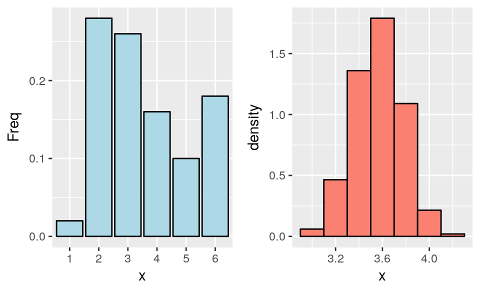

```r
n = 50
B = 1000
## our data
x = sample(1 : 6, n, replace = TRUE)

## bootstrap resamples
resamples = matrix(sample(x,
                           n * B,
                           replace = TRUE),
                    B, n)
resampledMeans = apply(resamples, 1, mean)

## plot sample histogram of 50 die rolls
g1 <- ggplot(as.data.frame(prop.table(table(x))), aes(x = x, y = Freq)) + geom_bar(colour = "black", fill = "lightblue", stat = "identity")

## plot histogram of 1000 bootstrap resamples for the mean
g2 <- ggplot(data.frame(x = resampledMeans), aes(x = x)) + geom_histogram(binwidth=.2, colour = "black", fill = "salmon", aes(y = ..density..))
grid.arrange(g1, g2, ncol = 2)
```

- *principle* = if a statistic’s (eg. median) sampling distribution is unknown, then use distribution defined by the data to approximate it
- *genereal procedure*
  1. simulate $n$ observations **with replacement** from the observed data $\rightarrow$ results in $1$ simulated complete data set
  2. calculate desired statistic (eg. median) for each simulated data set
  3. repeat the above steps $B$ times, resulting in $B$ simulated statistics (Monte Carlo simulation)
  4. these statistics are approximately drawn from the sampling distribution of the statistic of $n$ observations
  5. perform one of the following
     - plot a histogram
     - calculate standard deviation of the statistic to estimate its standard error
     - take quantiles (2.5<sup>th</sup> and 97.5<sup>th</sup>) as a confidence interval for the statistic (“*bootstrap CI*”)
- *Example*: Nonparametric bootstrap algorithm
  - Bootstrap procedure for calculating confidence interval for the median from a data set of $n$ observations $\rightarrow$ approximate sampling distribution

```r
# load data
library(UsingR); data(father.son)

# observed dataset
x <- father.son$sheight
n <- length(x)

# number of bootstrap resamples
B <- 10000

# simulating from an empirical distribution defined by our data that puts
# probability 1 over n on each observed data point
resamples <- matrix(
    sample(x,               # sample to draw from
           n * B,           # draw B datasets with n observations each
           replace = TRUE), # drawing with REPLACEMENT
    B, n)                   # arrange results into B x n matrix
                            # (every row = bootstrap sample with n observations)

# take median for each row/generated sample
medians <- apply(resamples, 1, median)

# estimated standard error of median
sd(medians)
```

```
## [1] 0.08467922
```

```r
# confidence interval of median
quantile(medians, c(.025, .975))
```

```
##     2.5%    97.5%
## 68.42972 68.81461
```

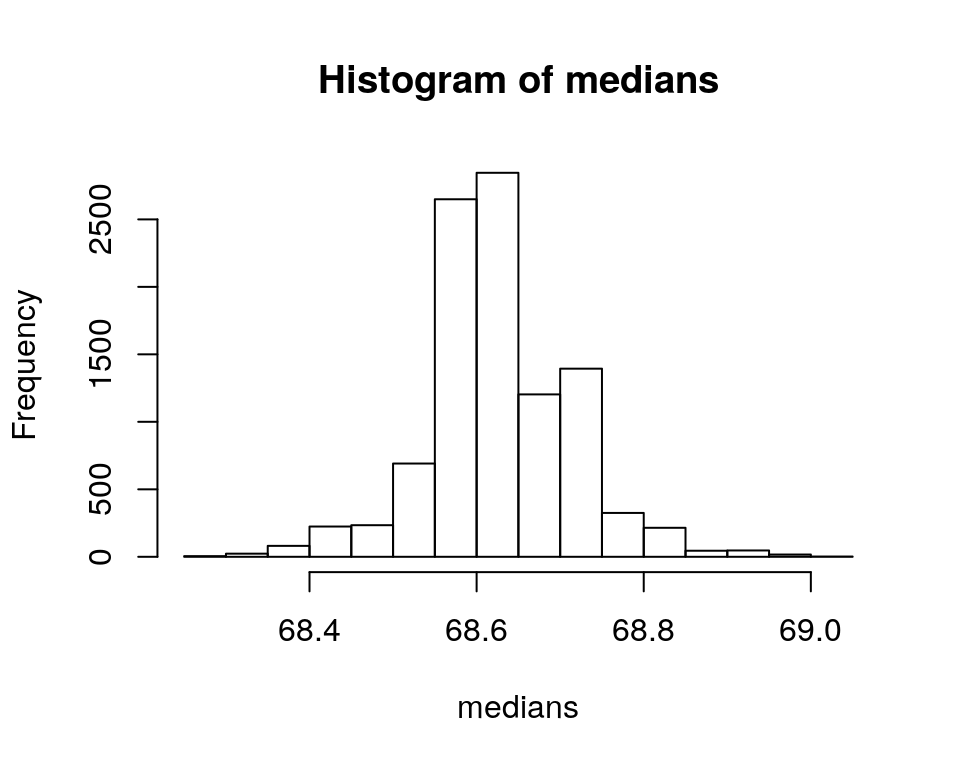

```r
# histogram of bootstraped samples
hist(medians)
```

- **Note:** better percentile bootstrap confidence interval = “bias corrected and accelerated interval” in `bootstrap` package (`bca` interval)
- **Further Resources**:
  - “An Introduction to the Bootstrap”" by Efron and Tibshirani is a great place to start for both bootstrap and jackknife information

## 16.2 Permutation Tests

- handy tool used in group comparisons. As bootstrapping did, permutation testing samples a single dataset a zillion times and calculates a statistic based on these samplings
- Permutation testing, however, is based on the idea of **exchangability of group labels**. It measures whether or not outcomes are independent of group identity. Our zillion samples simply permute group labels associated with outcomes.
- *procedures*
  - Consider the null hypothesis that the distribution of the observations from each group is the same
  - Compare the independent groups of data (eg. calculate mean difference in counts)
    - **Note**: if the null is true, then group labels/divisions are irrelevant
  - Permute the labels for the groups
  - Recalculate the statistic
    - Mean difference in counts
    - Geometric means
    - T statistic
  - Calculate the percentage of simulations where the simulated statistic was more extreme (toward the alternative) than the observed
- *variations*

| Data type | Statistic | Test name |
| --- | --- | --- |
| Ranks | rank sum | rank sum test |
| Binary | hypergeometric prob | Fisher’s exact test |
| Raw data |  | ordinary permutation test |

- **Note**: so-called **randomization** tests are exactly permutation tests, with a different motivation
- For matched data, one can randomize the signs
  - For ranks, this results in the **signed rank test**
- Permutation strategies work for regression by permuting a regressor of interest
- Permutation tests work very well in multivariate settings
- *Example*: Permutation test for pesticide data (Group comparisons)

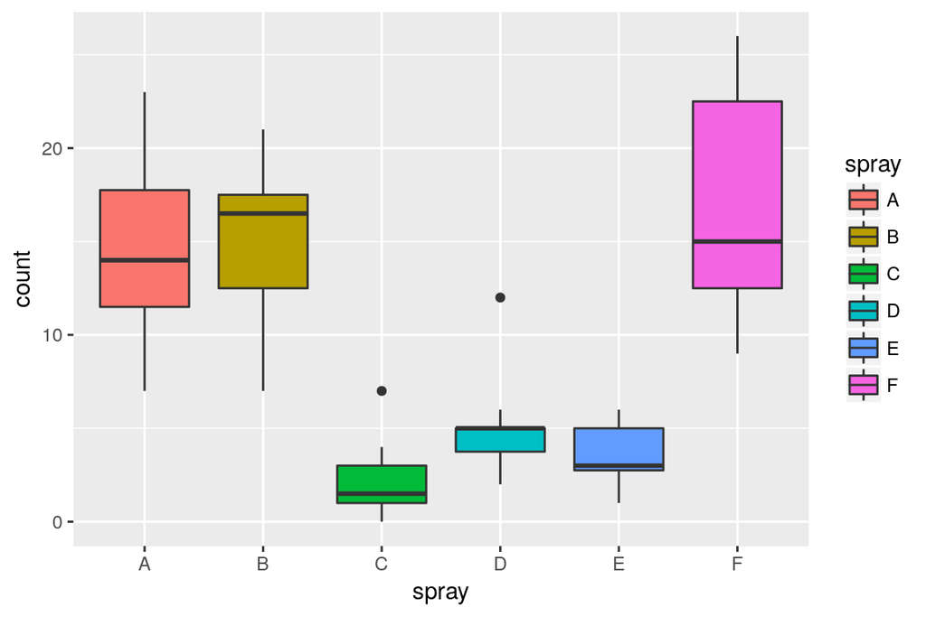

```r
# load data
data(InsectSprays)
# plot boxplot of dataset
ggplot(InsectSprays, aes(spray, count, fill = spray)) + geom_boxplot()
```

- we will compare groups **B** and **C** in this dataset for the null hypothesis $H_0:$ there are no difference between the groups (ie. means are the same)

```r
# subset to only "B" and "C" groups
subdata <- InsectSprays[InsectSprays$spray %in% c("B", "C"),]

# values
y <- subdata$count

# labels
group <- as.character(subdata$spray)

# find mean difference between the groups
testStat <- function(w, g) mean(w[g == "B"]) - mean(w[g == "C"])
observedStat <- testStat(y, group)
observedStat
```

```
## [1] 13.25
```

- the observed difference between the groups is 13.25, which means excess of 13 dead insects on average killed per batch for **B** versus **C**
  - (Sidenote: `mean(Bdata$count)-mean(Cdata$count)` equals `mean(Bdata$count-Cdata$count)`, because mean is linear)
- now we resample the lables for groups **B** and **C**

```r
# create 10000 permutations of the data with the labels changed
# we get 10000 test statistics (in our case mean differences)
permutations <- sapply(1 : 10000, function(i) testStat(y, sample(group)))
# calculate the percentage of our permuted test statistics that are larger or more extreme
# (in favor of the alternative) than the observed
mean(permutations > observedStat)
```

```
## [1] 0
```

- we created 10000 permutations from the observed dataset, and found *no datasets* with mean differences between groups **B** and **C** are larger than the original data
- therefore, p-value is very small, close to zero, so we can *reject the null* hypothesis that the means of the two sprays were equal with any reasonable $\alpha$ levels
- below is the plot for the null distribution generated by our permutations; vertical line represents the observed statistic (`observedStat`)

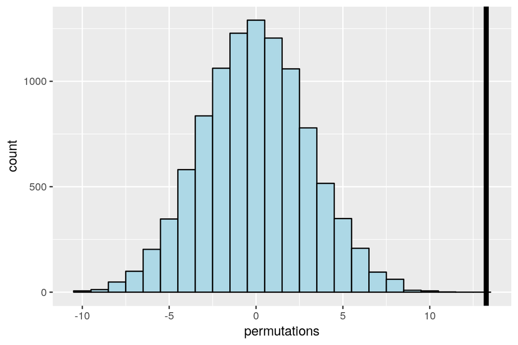

```r
# plot distribution of permutations
ggplot(data.frame(permutations = permutations),
           aes(permutations)) + geom_histogram(fill = "lightblue", color = "black", binwidth = 1) + geom_vline(xintercept = observedStat, size = 2)
```

- as we can see from the black line, the observed difference of means (our statistic) is very far in the tail of our null distribution, suggesting that likely the null distribution is not the correct true distribution in that B really is very different from C
  - This means that group identification did matter and sprays B and C were quite different.
  - we can just see that from the histogram but now we can quantify it with a P-value, and we can perform a formal hypothesis test

# 17 R Cheatsheet

**Overview**

- `rbinom()`, `rnorm()`, `rgamma()`, `rpois()`, `runif()` = functions to generate random variables from the binomial, normal, Gamma, Poisson, and uniform distributions
- `dbinom(k, n, p)` = return the probability of getting `k` successes out of `n` trials, given probability of success is `p`
- `dnorm()`, `dgamma()`, `dpois()`, `dunif()` = return probability of a certain value from the normal, Gamma, Poisson, and uniform distributions PDF = derivative of CDF
  - integrate PDF $\rightarrow$ CDF
    - `integrate(function, lower=0, upper=1)` $\rightarrow$ can be used to evaluate integrals for a specified range
- `pbinom()`, `pnorm()`, `pgamma()`, `ppois()`, `punif()` = returns the cumulative probabilities from 0 up to a specified value from the binomial, normal, Gamma, Poisson, and uniform distributions
- `qbeta(quantileInDecimals, 2, 1)` = returns quantiles for beta distribution
  - works for `qnorm()`, `qbinom()`, `qgamma()`, `qpois()`, etc.

**Binomial Distribution**

- `choose(8, 7)` = R function to calculate n choose x
- `pbinom(6, size=8, prob =0.5, lower.tail=TRUE)` = probability of 6 or less successes out of 8 samples with probability of 0.5 (**CDF**)
  - `lower.tail=FALSE` = returns the complement, in this case it’s the probability of greater than 6 successes out of 8 samples with probability of 0.5

**Normal Distribution**

- `qnorm(n, mean=mu, sd=sd)` = returns the $n^{th}$ percentiles for the given normal distribution
- `pnorm(x, mean=mu, sd=sd, lower.tail=F)` = returns the probability of an observation drawn from the given distribution is larger in value than the specified threshold $x$ (**CDF**)

**Poisson Distribution**

- `ppois(n, lambda = lambda*t)` = returns probability of $n$ or fewer events happening given the rate $\lambda$ and time $t$

**t Distribution**

- `qt(0.975, df=n-1)` = calculate the relevant quantile using t distribution

**Confidence Intervals**

- `binom.test(k, n)$conf.int` = returns confidence interval binomial distribution (collection of Bernoulli trial) with `k` successes in `n` draws
- `poisson.test(x, T)$conf` = returns Poisson 95% confidence interval for given `x` occurrence over `T` time period
- `t.test(difference)` = performs **group mean t test** and returns metrics as results, which includes the confidence intervals
  - `t.test(g2, g1, paired = TRUE, var.equal = FALSE)` = performs the same paired t test with data directly
    - *paired* = whether or not the two sets of data are paired (same subjects different observations for treatment) $\rightarrow$ `TRUE` for paired, `FALSE` for independent
    - *var.equal* = whether or not the variance of the datasets should be treated as equal
  - `t.test(extra ~ I(relevel(group, 2)), paired = TRUE, data = sleep)$conf.int` = same as above, but returns confidence interval
    - *relevel(factor, ref)* = reorders the levels in the factor so that “ref” is changed to the first level $\rightarrow$ doing this here is so that the second set of measurements come first (1, 2 $\rightarrow$ 2, 1) in order to perform mean$_2$ - mean$_1$
    - *I(object)* = prepend the class “AsIs” to the object
    - **Note**: I(relevel(group, 2)) = explanatory variable, must be **factor** and have **two levels**

**Hypothesis Testing**

- `t.test(x)`
  - `alternative` argument can be used to specify one-sided tests: `less` or `greater`
  - `alternative` default = `two-sided`
  - output:
    - test statistic (`t`), degrees of freedom (`df`), `p-value`, 95% confidence interval, and mean of sample

**P-Values**

- p-value = `pt(statistic, df, lower.tail = FALSE)`
  - `lower.tail = FALSE` = returns the probability of getting a value from the t distribution that is larger than the test statistic
- Binomial (coin flips)
  - probability of getting x results out of n trials and event probability of p = `pbinom(x-1, size=n, prob=p, lower.tail = FALSE)`
  - `x-1` is used here because the upper tail includes the specified number (since we want greater than x, we start at x - 1)
  - two-sided interval (testing for $\ne$): find the smaller of two one-sided intervals (X < value, X > value), and double the result
  - **Note**: `lower.tail = FALSE` = strictly greater
- Poisson
  - probability of getting x results given the rate r = `ppois(x-1, rate, lower.tail = FALSE)`
  - `x-1` is used here because the upper tail includes the specified number (since we want greater than x, we start at x - 1)
  - `rate` = events that should occur given the rate (multiplied by 100 to yield an integer)
  - **Note**: `lower.tail = FALSE` = strictly greater
  - alternatively: `poisson.test(10, T = 100, r = 0.05, alt="greater")$p.value`

**Power**

- Power = `pnorm(mu0 + z * sigma/sqrt(n), mean = mua, sd = sigma/sqrt(n), lower.tail = FALSE)` $\rightarrow$ calculates the probability of getting a sample mean that is larger than $\mu_0 + Z_{1-\alpha} \frac{\sigma}{\sqrt{n}}$ given that the population mean is $\mu_a$
- `power.t.test` = evaluates the non-central t distribution and solves for a parameter given all others are specified
  - `power.t.test(n = 16, delta = 0.5, sd = 1, type = "one.sample", alt = "one.sided")$power` = calculates power with inputs of n, difference in means, and standard deviation
    - `delta` = argument for **difference in means**
    - **Note**: since effect size = `delta/sd`, as `n`, `type`, and `alt` are held constant, any distribution with the same effect size will have the same power
  - `power.t.test(power = 0.8, delta = 0.5, sd = 1, type = "one.sample", alt = "one.sided")$n` = calculates size n with inputs of power, difference in means, and standard deviation
    - **Note**: n should always be rounded up (ceiling)

**adjusted p-values**

- Controlling FWER: `p.adjust(pValues, method="bonferroni")`
- Controlling FDR: `p.adjust(pValues, method="BH")`

# 18 Practice Examples

## 18.1 Example 1

Load the data set `mtcars` in the `datasets` R package. Assume that the data set mtcars is a random sample. Compute the mean MPG, $\bar x,$ of this sample.

You want to test whether the true MPG is $\mu_0$ or smaller using a one sided 5% level test. ($H_0 : \mu = \mu_0$ versus $H_a : \mu < \mu_0$). Using that data set and a Z test:

1. . Based on the mean MPG of the sample $\bar x,$ and by using a Z test: what is the smallest value of $\mu_0$ that you would reject for (to two decimal places)

**Answer**:

We want to solve
$$\frac{\sqrt{n}(\bar{X} - \mu_0)}{s} = Z_{0.05}$$
Or
$$\mu_0 = \bar{X} - Z_{0.05} s / \sqrt{n} = \bar{X} + Z_{0.95} s / \sqrt{n}$$
Note that the quantile is negative.

```r
mn <- mean(mtcars$mpg)
s <- sd(mtcars$mpg)
z <- qnorm(.05)
mu0 <- mn - z * s / sqrt(nrow(mtcars))
```

## 18.2 Example 2

Consider again the `mtcars` dataset. Use a two group t-test to test the hypothesis that the 4 and 6 cyl cars have the same mpg. Use a two sided test with unequal variances.

1. Do you reject at the 5% level (enter 0 for no, 1 for yes).
2. What is the P-value to 4 decimal places expressed as a proportion?

**Answer**:

```r
m4 <- mtcars$mpg[mtcars$cyl == 4]
m6 <- mtcars$mpg[mtcars$cyl == 6]
p <- t.test(m4, m6, paired = FALSE, alternative="two.sided", var.equal=FALSE)$p.value
```

## 18.3 Example 3

A sample of 100 men yielded an average PSA level of 3.0 with a sd of 1.1. What are the complete set of values that a 5% two sided Z test of $H_0 : \mu = \mu_0$ would fail to reject the null hypothesis for?

1. Enter the lower value to 2 decimal places.
2. Enter the upper value to 2 decimal places.

**Answer**:

```r
round(3 - qnorm(.975) * 1.1 / sqrt(100), 2)
```

```
## [1] 2.78
```

```r
round(3 + qnorm(.975) * 1.1 / sqrt(100), 2)
```

```
## [1] 3.22
```

## 18.4 Example 4

You believe the coin that you’re flipping is biased towards heads. You get 55 heads out of 100 flips.

1. What’s the exact relevant pvalue to 4 decimal places (expressed as a proportion)?
2. Would you reject a 1 sided hypothesis at $\alpha = .05$? (0 for no 1 for yes)?

**Answer**:

Note you have to start at 54 as it `lower.tail = FALSE` gives the strictly greater than probabilities

```r
round(pbinom(54, prob = .5, size = 100, lower.tail = FALSE),4)
```

```
## [1] 0.1841
```

## 18.5 Example 5

A web site was monitored for a year and it received 520 hits per day. In the first 30 days in the next year, the site received 15,800 hits. Assuming that web hits are Poisson.

1. Give an exact one sided P-value to the hypothesis that web hits are up this year over last to four significant digits (expressed as a proportion).
2. Does the one sided test reject (0 for no 1 for yes)?

**Answer**:

This test comes with the important assumption that web hits are a Poisson process.

```r
ppois(15800 - 1, lambda = 520 * 30, lower.tail = FALSE)
```

```
## [1] 0.05533114
```

Also, compare with the Gaussian approximation where $\hat \lambda \sim N(\lambda, \lambda / t)$

```r
pnorm(15800 / 30, mean = 520, sd = sqrt(520 / 30), lower.tail = FALSE)
```

```
## [1] 0.05465729
```

As $t\rightarrow \infty$ this becomes more Gaussian. The approximation is pretty good for this setting.

## 18.6 Example 6

Suppose that in an AB test, one advertising scheme led to an average of 10 purchases per day for a sample of 100 days, while the other led to 11 purchaces per day, also for a sample of 100 days. Assuming a common standard deviation of 4 purchases per day. Assuming that the groups are independent and that they days are iid, perform a Z test of equivalence.

1. What is the P-value reported to 3 digits expressed as a proportion?
2. Do you reject the test? (0 for no 1 for yes).

**Answer**:

```r
m1 <- 10; m2 <- 11
n1 <- n2 <- 100
s <- 4
se <- s * sqrt(1 / n1 + 1 / n2)
ts <- (m2 - m1) / se
pv <- 2 * pnorm(-abs(ts))
```

## 18.7 Example 7

Consider two problems previous. Assuming that 10 purchases per day is a benchmark null value, that days are iid and that the standard deviation is 4 purchases for day. Suppose that you plan on sampling 100 days. What would be the power for a one sided 5% Z mean test that purchases per day have increased under the alternative of $\mu = 11$ purchase per day?

1. Give your result as a proportion to 3 decimal places.

**Answer**:

```r
power <- pnorm(10 + qnorm(.95) * .4, mean = 11, sd = .4, lower.tail = FALSE)
```

## 18.8 Example 8

Researchers would like to conduct a study of healthy adults to detect a four year mean brain volume loss of .01 mm3. Assume that the standard deviation of four year volume loss in this population is .04 mm3.

1. What is necessary sample size for the study for a 5% one sided test versus a null hypothesis of no volume loss to achieve 80% power? (Always round up)

**Answer**:

Under $H_0$ $\bar X$ is $N(0, .04 / \sqrt{n})$ and is $N(.01, .04 / \sqrt{n})$ under $H_a$. We will reject if
$$\bar X \geq z_{.95} s / \sqrt(n)$$
which has probability 0.05 under $H_0$. Under $H_a$ it has probability
$$P\left( \frac{\bar X - 0.01}{s / \sqrt{n}} \geq z_{.95} - \frac{0.01}{s / \sqrt{n}} \right)
= P\left( Z \geq z_{.95} - \frac{0.01}{s / \sqrt{n}}\right) = 1 - P\left( Z < z_{.95} - \frac{0.01}{s / \sqrt{n}}\right) = 0.8$$

$$1 - \Phi \left(z_{.95} - \frac{0.01}{s / \sqrt{n}} \right) = 0.8$$

$$\Phi \left(z_{.95} - \frac{0.01}{s / \sqrt{n}} \right) = 0.2$$

$$z_{.95} - \frac{0.01}{s / \sqrt{n}} = \Phi^{-1} (0.2) = z_{.2}$$

$$n = \frac{(z_{.95} - z_{.2})^2 s^2}{0.01^2} = \frac{ (z_{.95} + z_{.8})^2 s^2}{.01^2}$$
So we get

```r
n <- (qnorm(.95) + qnorm(.8)) ^ 2 * .04 ^ 2 / .01^2
```

## 18.9 Example 9

Consider the `mtcars` data set.

1. Give the p-value for a t-test comparing MPG for 6 and 8 cylinder cars assuming equal variance, as a proportion to 3 decimal places.
2. Give the associated P-value for a z test.
3. Give the common (pooled) standard deviation estimate for MPG across cylinders to 3 decimal places.
4. Would the t test reject at the two sided 0.05 level (0 for no 1 for yes)?

**Answer**:

```r
mpg8 <- mtcars$mpg[mtcars$cyl == 8]
mpg6 <- mtcars$mpg[mtcars$cyl == 6]
m8 <- mean(mpg8); m6 <- mean(mpg6)
s8 <- sd(mpg8); s6 <- sd(mpg6)
n8 <- length(mpg8); n6 <- length(mpg6)

p <- t.test(mpg8, mpg6, paired = FALSE, alternative="two.sided", var.equal=TRUE)$p.value
mixprob <- (n8 - 1) / (n8 + n6 - 2)
s <- sqrt(mixprob * s8 ^ 2  +  (1 - mixprob) * s6 ^ 2)
z <- (m8 - m6) / (s * sqrt(1 / n8 + 1 / n6))
pz <- 2 * pnorm(-abs(z))
## Hand calculating the T just to check
#2 * pt(-abs(z), df = n8 + n6 - 2)
```